# ¿Brujas o guardianas de la noche? El enigma del vuelo nocturno

Melanny Moreno

2025-10-06

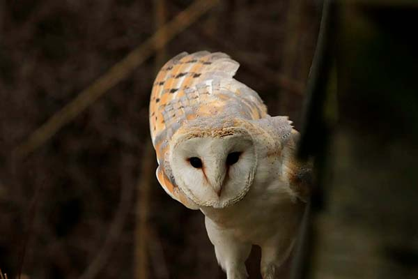

LECHUZA

# INTRODUCCION

Circula en redes sociales un video en el que una persona le grita a un gran animal emplumado de color grisáceo: “¿Eres una bruja? ¡Responde! ¿Eres una bruja?”. Después se puede oír el sonido desgarrador del animal, que abre sus alas y parece que se hace más grande.

Según la creencia popular, las brujas suelen transformarse en animales, generalmente en lechuzas, volar por las noches y posarse sobre los árboles o los techos de las casas y mirar por la ventana, esperando el momento perfecto para atacar a los más vulnerables de los hogares. Existen diversas leyendas acerca de estos seres mitológicos de México, algunas historias señalan que las lechuzas son compañeras de las brujas y, por eso, escuchar su canto es considerado un mal presagio.

Lo cierto es que estas aves nocturnas, cuyo nombre científico es Tyto alba, son excelentes controladoras de plagas en los ecosistemas. Además, realmente es hermoso verlas extender sus alas durante una noche estrellada, en donde el color de su plumaje brilla en la oscuridad: nos referimos a las lechuzas de campanario, que están presentes en todo México.

Lamentablemente, las lechuzas de campanario han sido cazadas y maltratadas durante muchos años debido a estas creencias. Para desmitificar estas ideas, Revista Gaceta UAEH entrevistó a la profesora investigadora Iriana Zuria, así como a la estudiante Ariday Aguilar, quienes realizan investigación sobre esta ave, y otras más, en el Centro de Investigaciones Biológicas (CIB) de la Universidad Autónoma del Estado de Hidalgo (UAEH).

# LAS LECHUZAS EN LA CULTURA MEXICANA

Las lechuzas, junto con los búhos y tecolotes, forman parte del orden de los Strigiformes. Su particular aspecto blanco y sus grandes ojos oscuros, sumado a su hábito de anidar en iglesias y otras estructuras humanas, la han hecho objeto de supersticiones.

“La llaman bruja porque su vuelo es muy silencioso, por lo que algunas personas mencionan que parecen espíritus flotantes”, comentó la científica Iriana Zuria en la entrevista, quien agregó que su canto áspero, y espeluznante en la noche, refuerza la creencia de que se convierten en brujas.

Parte del misterio que las rodea está en sus características únicas. Son grandes aves, principalmente nocturnas, con adaptaciones que les permiten cazar con una precisión sorprendente. Una de sus habilidades más destacadas es su capacidad de volar sin hacer ruido. Sus plumas están especialmente adaptadas para amortiguar el sonido, lo que les permite acercarse a sus presas sin ser detectadas, detalle que ha contribuido a su aura de invisibilidad y sigilo.

Su particular forma facial, similar a un “antifaz”, actúa como una especie de antena parabólica que captura sonidos, permitiéndoles detectar a sus presas, como roedores y pequeños mamíferos, incluso en la más completa oscuridad. Esta adaptación, sumada a su capacidad para ver en la oscuridad, las convierte en cazadoras nocturnas letales, lo que, desde tiempos antiguos, ha sido malinterpretado como un poder sobrenatural.

Sin embargo, no todas las aves rapaces son nocturnas, existen especies diurnas, como el tecolote llanero (Athene cunicularia), que prefiere cazar durante el día y anida en madrigueras bajo tierra. Esta especie, común en México, ha dado lugar a otro popular dicho: “Cuando el tecolote canta, el indio muere”. Aunque su canto diurno no tiene nada de mágico, el mito persiste en la tradición oral.

Es importante destacar que la ciudad de Pachuca cuenta con un gran número de tecolotes llaneros, los cuales se han podido visualizar de manera más recurrente en puntos como la Zona Plateada y el sur de la capital.

# ROL ECOLOGICO

Lejos de ser mensajeras de la muerte o seres malvados, las lechuzas cumplen un papel crucial en los ecosistemas: son depredadoras naturales que ayudan a controlar poblaciones de roedores y otras plagas que podrían afectar cultivos o propagar enfermedades. Es conocida por su dieta rica en ratas y ratones, lo que la convierte en una gran aliada para las y los agricultores al mantener bajo control las poblaciones de plagas.

Desafortunadamente, debido a los mitos y leyendas que las rodean, algunas personas las capturan o incluso las matan por temor, lo que afecta aún más sus poblaciones.

Al respecto, la alumna de la Licenciatura en Biología, Ariday Aguilar, quien actualmente desarrolla la tesis “Lechuzas de Campanario, percepción popular, distribución y dieta”, señaló que al realizar encuestas, más de una persona entrevistada admitió haber matado a una lechuza o conocer a alguien que lo hizo por estas creencias infundadas.

Para cerrar, Ariday Aguilar recomendó a la sociedad en general que si se encuentra un ejemplar lastimado acuda a las unidades de rehabilitación especializadas, como la ubicada en el Bioparque de Convivencia en Pachuca. También, pueden comunicarse directamente con la Procuraduría Federal de Protección al Ambiente (PROFEPA) o acudir a los bomberos, quienes cuentan con un protocolo específico para estos casos.

Aunado a ello, existe la Ley General de Vida Silvestre, que establece sanciones específicas para aquellos que causen algún daño a estos animales.

Durante el Día de Muertos, una festividad que honra a las y los seres queridos fallecidos, las lechuzas representan un enlace entre el mundo de los vivos y el de los muertos, según las creencias populares. Sin embargo, más allá del mito, es fundamental reconocer el valor que estas aves aportan a nuestro entorno. Como guardianas nocturnas, protegen los cultivos y controlan plagas, contribuyendo al equilibrio natural.

En lugar de temerlas, quizás deberíamos ver en su presencia un símbolo de armonía con la naturaleza, y valorar la suerte de poder observar una lechuza en su majestuoso vuelo nocturno. Después de todo, si aún vuelan entre nosotros, es señal de que nuestros ecosistemas aún conservan algo de su equilibrio original.